# ECE 5470 Lab 6 Report: 3D Image Processing

by Junjie Tian

```python
import numpy as np
from v4 import vx
from v4 import vd
```

### Section 2. Three-dimensional filtering

```python
exec(vx.vxsh('t1makepy'))
```

```python
# Review the contents of t1.vd
exec(vx.vxsh('vps t1.vd of=t1_vps'))
exec(vx.vxsh('vpr t1.vd -t'))
```

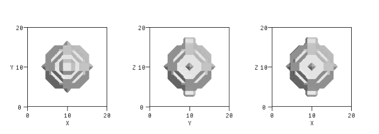

```
Demonstration of cardinal views
<scaled size: (258 x 772) >
```

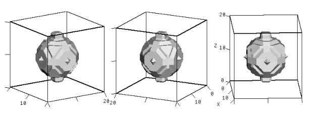

```
Demonstraion of selected views
<scaled size: (256 x 768) >
```

```python
# Compute three different visualizations using v3view
exec(vx.vxsh('v3view if=t1.vd of=t1vis.vx'))
exec(vx.vxsh('v3view -yo if=t1.vd ang=120 | vtile n=3,1 of=t1vis.vs '))
exec(vx.vxsh('v3view -yo -gif if=t1.vd of=t1vis.gif'))
vd.dispmvx('t1vis.vx', capt='Demonstration of cardinal views')
vd.dispmvx('t1vis.vs', capt='Demonstraion of selected views')
```

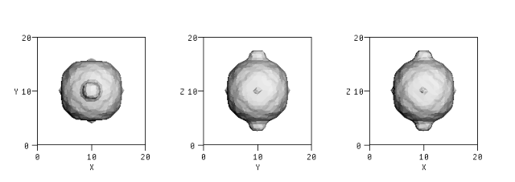

```
Smoothed image
<scaled size: (258 x 772) >
```

```python
# Smooth the polygons to achieve a better looking object
exec(vx.vxsh('v3pfilt -a t1.vd -o t1f.vd'))
exec(vx.vxsh('v3view  t1f.vd of=t1f.vx'))
vd.dispmvx('t1f.vx', capt='Smoothed image')
```

Discussion: The graph 't1f.vd' is smoother than the 't1.vd'. For the cubical shapes, the sharp edges become smooth quarter circle shapes. This shows that the function 'v3pfilt' can successfully make the polygons to be smoother and look better. I won't always want to perform this action on polygons. When I don't care much about the actual parameters and wish to present the object to other people in an appealing and nice-looking way, it is suitable to use the algorithm. However, if the accurate parameters of each part of the object is needed, such as in manufacturing and laboratory experiments, it is not suitable to perform such an action, as precise information is needed.

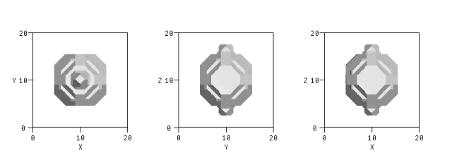

```
Morphological filtering with s=3,3,3
<scaled size: (258 x 772) >
```

```python
# Three-dimensional morphological filtering
exec(vx.vxsh('vmorph t1.vx -ed t=s s=3,3,3 | vdim -c  of=n3.vx'))
exec(vx.vxsh('v3pol -t if=n3.vx of=n3.vd'))
# visualize  the result
exec(vx.vxsh('v3view n3.vd of=n3.vx'))
vd.dispmvx('n3.vx', capt='Morphological filtering with s=3,3,3')
```

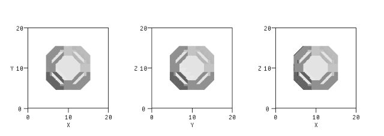

```
Morphological filtering with s=8,8,8 (Cardinal Views)
<scaled size: (258 x 772) >
```

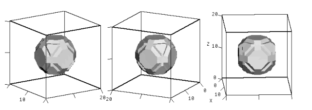

```
Morphological filtering with s=8,8,8 (Selected Views)
<scaled size: (256 x 768) >
```

```python
# Try different parameters in morphological filtering
exec(vx.vxsh('vmorph t1.vx -ed t=s s=8,8,8 | vdim -c  of=n8.vx'))
exec(vx.vxsh('v3pol -t if=n8.vx of=n8.vd'))

# visualize  the result
exec(vx.vxsh('v3view n8.vd of=n8.vx'))
vd.dispmvx('n8.vx', capt='Morphological filtering with s=8,8,8 (Cardinal Views)')

# visualize in a different angle
exec(vx.vxsh('v3view -yo if=n8.vd ang=120 | vtile n=3,1 of=n8_angle.vs '))
vd.dispmvx('n8_angle.vs', capt='Morphological filtering with s=8,8,8 (Selected Views)')
```

Discussion: The vmorph doesn't remove the protrusions. The possible reason is that the value of 's=3,3,3' is not large enough (i.e. the size of the kernel is not large enough). I tried to increase the value to 8 ('s=8,8,8'), and the protrusions were removed. However, when we inspect the output image in a different angle, I find that the structure of the object in parts other than the original protrusion parts are also altered. The hollow part on the side of the object is filled in the output image. The possible reason is that there is a parameter '-ed' in the function, which means we are performing opening to remove small objects and preserve large objects. Therefore, the protrusions are considered 'small' and are removed; the hollow parts are also considered 'small' and are removed.

### Section 3 Three-dimensional Edge Detector

#### 3.1 3D edge detection algorithm

```python
# program goes here
'''
#!/usr/bin/env python

""" v3edge: 3x3x3  edge detector for 3D images

"""
from v4 import vx
import sys
import numpy as np

def v3low ( img ):
 """ low pass filter
 """
 im = img.i
 tmimage = vx.Vx( img )
 tm = tmimage.i
 for z in range(1, im.shape[0]):
     for y in range(1, im.shape[1]):
         for x in range(1, im.shape[2]):
             if tm[z,y,x] >= 128:
                 im[z,y,x] = 255
             else:
                 im[z,y,x] = tm[z,y,x] / 128 * 255


def v3edge ( img ) :
 """ compute 3x3x3 mean for vx.Vx struct
 """
 im = img.i
 tmimage = vx.Vx( img )
 tmimage.embedim((1,1,1,1,1,1))
 tm = tmimage.i
 for z in range(1, im.shape[0]):
    for y in range(1, im.shape[1]):
        for x in range(1, im.shape[2]):
            # Calculate partial derivative in x,y,z directions
            gz = abs(tm[z, y, x] - tm[z+1, y, x]) + abs(tm[z, y, x] - tm[z-1, y, x])
            gy = abs(tm[z, y, x] - tm[z, y+1, x]) + abs(tm[z, y, x] - tm[z, y-1, x])
            gx = abs(tm[z, y, x] - tm[z, y, x+1]) + abs(tm[z, y, x] - tm[z, y, x-1])

            im[z, y, x] = gx + gy + gz

vargs = vx.vaparse( "if= of= -v  - ")
if '-' in vargs:
   print ("v3edge 3D edge detector")
   print ("if= input file")
   print ("of= output file")
   print ("[-v] verbose mode")
   sys.exit(0)

for arg in ['if', 'of']:
   if arg not in vargs:
       print ('v3edge error: required parameter %s is missing' % arg)
       sys.exit(1)
optv = '-v' in vargs

ximage = vx.Vx( vargs['if'] )   ;#read image
v3low(ximage);
v3edge(ximage)                 ;#process image
if optv:
   print (ximage.i)             ;# for very small images
ximage.write(vargs['of'])       ;# Write the result file
'''

# In this v3edge program, I first do low-pass filtering an then perform gradient estimation. Post-processing is applied later.
```

[output not shown]

#### 3.2 Experiments and Results

```python
# Add noise to t1.vx
exec(vx.vxsh('t2makepy'))
```

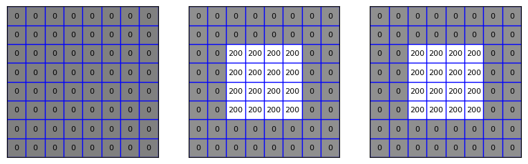

```
<scaled size: (8 x 8) (8 x 8) (8 x 8) >
```

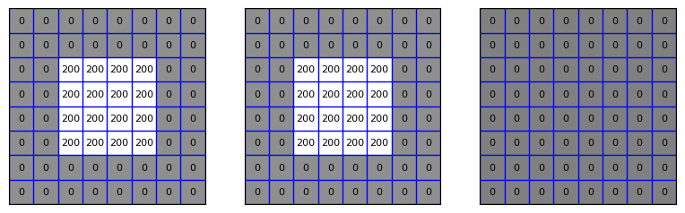

```
3D test image
<scaled size: (8 x 8) (8 x 8) (8 x 8) >
```

```python
# generate a test image for v3dedge
exec(vx.vxsh('vgenim s=8 z=6 r=2,2,2 of=tst1 hi=200'))

# visualize the test image for JN
tim = vx.Vx('tst1')
vd.dispsvx(tim.i[0], tim.i[1], tim.i[2])
vd.dispsvx(tim.i[3], tim.i[4], tim.i[5], capt='3D test image')
```

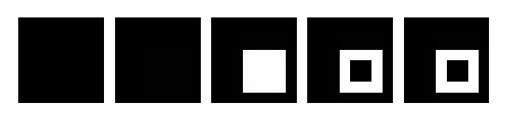

```
Edge detector on test image
<scaled size: (10 x 46) >
```

```python
exec(vx.vxsh('v3edge if=tst1 of=tst1_edge'))
exec(vx.vxsh(' vtile if=tst1_edge -ib n=5,1 -xb of=tst1_edge_display'))
vd.dispmvx('tst1_edge_display', capt='Edge detector on test image')
```

Discussion: In the small test image, the program of edge detector works as expected. The edges should be a hollow square around the center 4*4 shape with 200, which is shown in the output. As we are calculating the gradient considering the image before and after the current image, the edges are blurry in the third output image, but it becomes clearer in the fourth and fifth images.

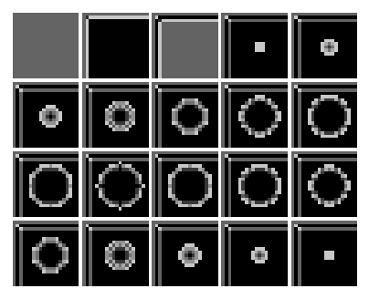

```
Edge detector on t1g.vx
<scaled size: (85 x 106) >
```

```python
# Implement v3edge on t1g.vx
exec(vx.vxsh('v3edge if=t1g.vx of=t1g_edge'))
exec(vx.vxsh(' vtile if=t1g_edge -ib n=5,4 -xb of=t1g_edge_display'))
vd.dispmvx('t1g_edge_display', capt='Edge detector on t1g.vx')
```

Discussion: The edge detector program works well on t1g.vx and edges are shown in white color clearly. Post processing is applied to the t1n.vx.

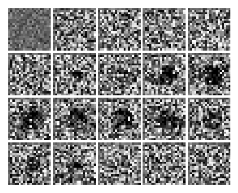

```
Edge detector on t1n.vx
<scaled size: (85 x 106) >
```

```python
# Implement v3edge on t1n.vx
exec(vx.vxsh('v3edge if=t1n.vx of=t1n_edge'))
exec(vx.vxsh(' vtile if=t1n_edge -ib n=5,4 -xb of=t1n_edge_display'))
vd.dispmvx('t1n_edge_display', capt='Edge detector on t1n.vx')
```

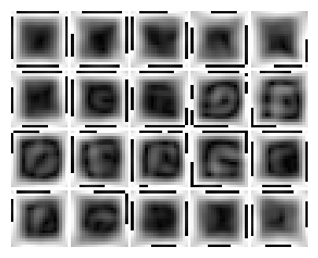

```
Post processing on t1n.vx
<scaled size: (85 x 106) >
```

```python
# Try a=0.5, 0.75, 1, 1.25, 1.5 and see which one is the best parameter.
exec(vx.vxsh('vderiche if=t1n_edge of=t1n_pro a=0.5'))
exec(vx.vxsh(' vtile if=t1n_pro -ib n=5,4 -xb of=t1n_pro_display'))
vd.dispmvx('t1n_pro_display', capt='Post processing on t1n.vx')
```

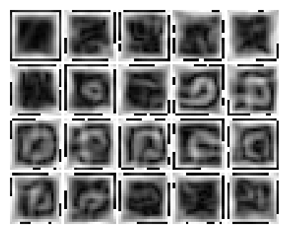

```
Post processing on t1n.vx
<scaled size: (85 x 106) >
```

```python
# Try a=0.5, 0.75, 1, 1.25, 1.5 and see which one is the best parameter.
exec(vx.vxsh('vderiche if=t1n_edge of=t1n_pro a=0.75'))
exec(vx.vxsh(' vtile if=t1n_pro -ib n=5,4 -xb of=t1n_pro_display'))
vd.dispmvx('t1n_pro_display', capt='Post processing on t1n.vx')
```

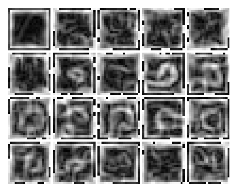

```
Post processing on t1n.vx
<scaled size: (85 x 106) >
```

```python
# Try a=0.5, 0.75, 1, 1.25, 1.5 and see which one is the best parameter.
exec(vx.vxsh('vderiche if=t1n_edge of=t1n_pro a=1'))
exec(vx.vxsh(' vtile if=t1n_pro -ib n=5,4 -xb of=t1n_pro_display'))
vd.dispmvx('t1n_pro_display', capt='Post processing on t1n.vx')
```

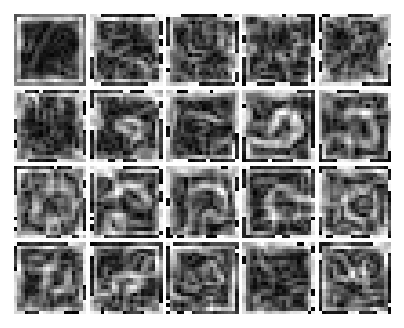

```
Post processing on t1n.vx
<scaled size: (85 x 106) >
```

```python
# Try a=0.5, 0.75, 1, 1.25, 1.5 and see which one is the best parameter.
exec(vx.vxsh('vderiche if=t1n_edge of=t1n_pro a=1.25'))
exec(vx.vxsh(' vtile if=t1n_pro -ib n=5,4 -xb of=t1n_pro_display'))
vd.dispmvx('t1n_pro_display', capt='Post processing on t1n.vx')
```

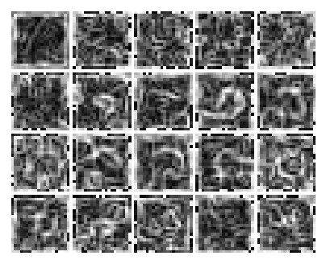

```
Post processing on t1n.vx
<scaled size: (85 x 106) >
```

```python
# Try a=0.5, 0.75, 1, 1.25, 1.5 and see which one is the best parameter.
exec(vx.vxsh('vderiche if=t1n_edge of=t1n_pro a=1.5'))
exec(vx.vxsh(' vtile if=t1n_pro -ib n=5,4 -xb of=t1n_pro_display'))
vd.dispmvx('t1n_pro_display', capt='Post processing on t1n.vx')
```

Discussion: Based on the above process, we determine that implementing vderiche with a=0.75 can give us the most clear edges output. The whole process of edge detector is shown again below.

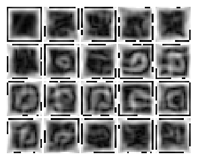

```
Post processing on t1n.vx
<scaled size: (85 x 106) >
```

```python
# Whole process of implementing edge detector
exec(vx.vxsh('v3edge if=t1n.vx of=t1n_edge'))
exec(vx.vxsh('vderiche if=t1n_edge of=t1n_pro a=0.75'))
exec(vx.vxsh(' vtile if=t1n_pro -ib n=5,4 -xb of=t1n_pro_display'))
vd.dispmvx('t1n_pro_display', capt='Post processing on t1n.vx')
```

### 4.Three-dimensional Segmetnation Evaluation

```python
# analsegpy
exec(vx.vxsh('analsegpy'))
```

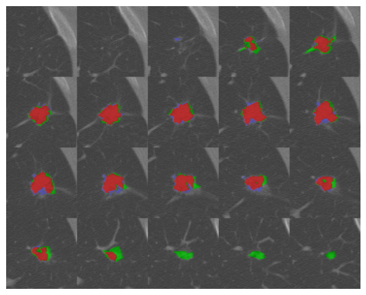

```
dcompare.vx
<scaled size: (292 x 365) >
```

```python
# Image dcompare.vx
vd.dispmvx('dcompare.vx', size=1.5, capt='dcompare.vx')
```

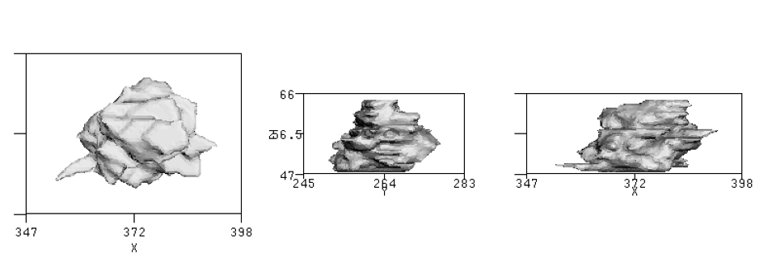

```
dmregion.vx
<scaled size: (258 x 772) >
```

```python
# Image dmregion.vx
vd.dispmvx('dmregion.vx', size=1.5, capt='dmregion.vx')
```

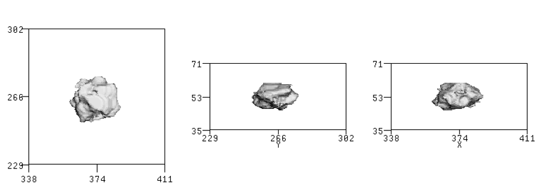

```
dnodseg.vx
<scaled size: (258 x 772) >
```

```python
# Image dnodseg.vx
vd.dispmvx('dnodseg.vx', size=1.5, capt='dnodseg.vx')
```

The output of compare.txt apcnt 4537 bpcnt 3849 overlap 3388 anotb 1149 bnota 461 union 4998 diff 1610 tp 3388 tn 186846 fp 1149 fn 461 fpc 0.58171 sim 0.67787 sens 0.88023 spec 0.99389 jin 0.67787 dsc 0.80801Discussion: Based on the compare.txt file, I include more pixels than the correct file. There are 3849 pixels in bf and 4537 pixels in if. There are 1149 pixels that are in my image but not in correct image; there are 461 pixels that are in the correct image but not in my image. The main reason is that I include more pictures than the correct answer when the nodule size becomes smaller; besides, I don't include enough edges of nodules. The fraction of pixels correct is only about 0.582, and the main reason is that there are a lot of pixels that are not overlapped between my answer and the correct answer. As the number of pixels that I include incorrectly is greater than the number of pixels I missed, I cover most of the correct region. Therefore, the sensitivity value is relatively high (about 0.880). The specificity value is very high (about 0.994) as the true negative region is very large (the region that is not nodule).